# Lowest Common Ancestor

Prof. Harbert

Section 2: Part 4

# Thanks [xkcd](https://xkcd.com)

[figure not shown]

# Goals

- Develop a simple algorithm to identify the Lowest Common Ancestor for each read in our BLAST results.
- Practice more dplyr

# LCA

Recall that our BLAST results can be classified to the NCBI taxonomy (we used taxonomizr). The resulting table has columns for superkingdom, phylum, class, order, family, genus, and species.

```r
download.file('https://zenodo.org/record/3686052/files/blasthits2.tab.gz?download=1',overwrite=T, destfile = 'blasthits2.tab.gz')
system('gunzip blasthits2.tab.gz')
blasthits = read.table('blasthits2.tab')
head(blasthits)
```

|  | QueryID | SubjectID | Perc.Ident | Alignment.Length | Mismatches | Gap.Openings | Q.start | Q.end | S.start | S.end | E | Bits | superkingdom | phylum | class | order | family | genus | species |
| --- | --- | --- | --- | --- | --- | --- | --- | --- | --- | --- | --- | --- | --- | --- | --- | --- | --- | --- | --- |
| 1 | Query_1 | KX167581.1 | 80.585 | 376 | 39 | 28 | 94 | 447 | 364 | 1 | 6.46e-65 | 259 | Eukaryota | Streptophyta | NA | Lamiales | Plantaginaceae | Callitriche | Callitriche stagnalis |
| 2 | Query_1 | KX165613.1 | 80.585 | 376 | 39 | 28 | 94 | 447 | 364 | 1 | 6.46e-65 | 259 | Eukaryota | Streptophyta | NA | Lamiales | Plantaginaceae | Callitriche | Callitriche stagnalis |
| 3 | Query_1 | KX165571.1 | 80.585 | 376 | 39 | 28 | 94 | 447 | 364 | 1 | 6.46e-65 | 259 | Eukaryota | Streptophyta | NA | Lamiales | Plantaginaceae | Callitriche | Callitriche stagnalis |
| 4 | Query_1 | LC177741.1 | 80.645 | 372 | 38 | 28 | 117 | 468 | 706 | 349 | 2.32e-64 | 257 | Eukaryota | Streptophyta | NA | Lamiales | Plantaginaceae | Callitriche | Callitriche stagnalis |
| 5 | Query_1 | LC177740.1 | 80.645 | 372 | 38 | 28 | 117 | 468 | 704 | 347 | 2.32e-64 | 257 | Eukaryota | Streptophyta | NA | Lamiales | Plantaginaceae | Callitriche | Callitriche stagnalis |
| 6 | Query_1 | MG217415.1 | 79.772 | 351 | 38 | 27 | 117 | 447 | 338 | 1 | 5.06e-56 | 230 | Eukaryota | Streptophyta | NA | Lamiales | Plantaginaceae | Callitriche | Callitriche stagnalis |

We want to write code to figure out how many names there are in each column for each read that has one match or more.

## The Search

Split the table into chunks by read groups:

```r
library(dplyr)
listhits = blasthits[1:1000,] %>%
  group_by(QueryID) %>%
  group_split()
```

How many names are there in each taxonomy column?

```r
# find the column that doesn't change
# taxonomy column names:
taxnames = c('superkingdom', 'phylum', 'order', 'family', 'genus', 'species')
shortnames = apply(listhits[[1]][,taxnames], 2, unique)
countshnames = sapply(shortnames, length)
```

Which is the last column that has only one name and what’s the name in it?

```r
lastuni = tail(names(countshnames[countshnames==1]), n=1)
lastuni
```

```
## [1] "genus"
```

```r
listhits[[1]][1,lastuni]
```

| genus |
| --- |
| Callitriche |

## Functionize It

Put that together:

```r
lca = function(x) {
  taxnames = c('superkingdom', 'phylum', 'order', 'family', 'genus', 'species')
  shortnames = apply(x, 2, unique)
  countshnames = sapply(shortnames, length)
  lastuni = tail(names(countshnames[countshnames==1]), n=1)
  nombre = as.data.frame(x[1,which(colnames(x) == lastuni)])
  ret = x %>%
    mutate(last_common = as.character(nombre[[1]])) %>%
    mutate(level_lca = lastuni)
  return(ret)
}

# then use group_modify to evaluate each read group and return a modified section of the table.
listhits = blasthits[1:10000,] %>%
  group_by(QueryID) %>%
  group_modify(~ lca(.x))
```

## Visualize

Summarise read counts for each lowest common ancestor taxon.

```r
#Analyze first part of the results
allhits = blasthits[1:500000,] %>%
  group_by(QueryID) %>%
  group_modify(~ lca(.x)) %>%
  slice(1) %>% #keep only first row in each group (one per read)
  group_by(last_common) %>% # group by LCA taxon
  summarize(lca_count = n()) %>% # count num reads (rows) for each LCA
  arrange(desc(lca_count)) # sort descending
```

- This takes a while. We may benefit from exploring parallel processing at this stage: https://github.com/tidyverse/multidplyr

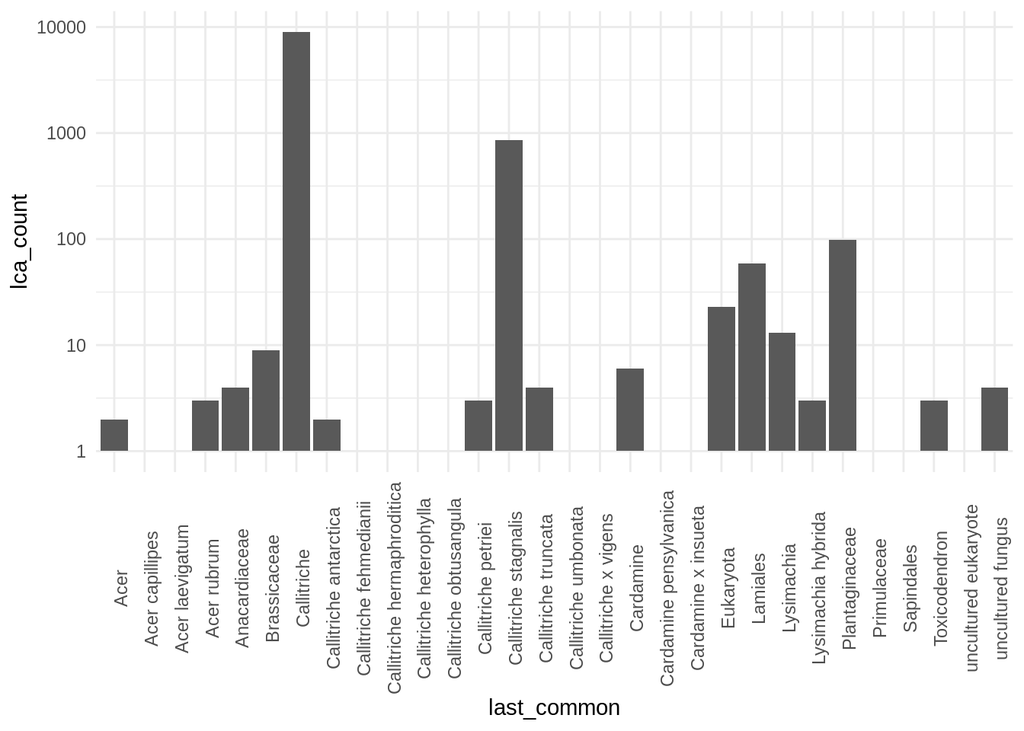

```r
library(ggplot2)
(lca_plot = ggplot(allhits %>% filter(!is.na(last_common)) ) +
  geom_col(aes(x=last_common, y=lca_count))) +
  scale_y_log10() +
  theme_minimal() +
  theme(axis.text.x = element_text(angle=90))
```

The plot shows that we are highly confident in the presence of *Callitriche* and that there are many reads that match to *Callitriche stagnalis* unambiguously. These results show that we are not very confident in the presence of other genera, but *Cardamine* (in the Brassicaceae), *Lysimachia* (Primulaceae, several native and non-native species present in Massachusetts), and *Toxicodentron* (poison ivy, known to be present near this site) are also present but identified by many fewer reads.

SAVE YOUR PLOT:

```r
ggsave(lca_plot, file='lca_plot.png', height=8, width=8, dpi=700)
```

# Future Work:

This LCA method suffers from a few logistical issues:

- First, it is difficult to count nested taxonomy with this. The reads that map unambiguously in a genus are then NOT counted in the read count for each family, order, etc. While the graph above shows which taxa we are most confident in it is not a good representation of how confident we are of which higher level taxa (families/orders) are present. At least not as written here.
- Second, the code is slow enough on a large blasthits table that it might be worth exploring options for parallel processing to speed up execution time on HPC resources.
- Annoying: the ggplot orders the x axis alphabetically, not by height of bar.

We will look into fixing this further next class.

# Homework:

Try the LCA code on a BLAST search with another eDNA fastq file. Post results image to Slack [#discussion](https://bio332applied-4mi2242.slack.com/archives/CS8TRGE0K).

[home](https://bio332.devbioinformatics.org)